# Data Visualization for King Country, USA dataset

Norden Sherpa

```r
# load necessary library
library(dplyr)
library(ggplot2)
library(ggcorrplot)
library(reshape2)
library(lubridate)
```

```r
# Reading the cleaned dataset
cleaned_data_file <- read.csv("cleaned_data_file.csv")
```

```r
# Checking the structure of the dataset
str(cleaned_data_file)
```

```
'data.frame':   20467 obs. of  13 variables:
 $ date         : chr  "2014-10-13" "2014-12-09" "2015-02-25" "2014-12-09" ...
 $ bedrooms     : int  3 3 2 4 3 3 3 3 3 3 ...
 $ bathrooms    : num  1 2.25 1 3 2 2.25 1.5 1 2.5 2.5 ...
 $ sqft_living  : int  1180 2570 770 1960 1680 1715 1060 1780 1890 3560 ...
 $ floors       : num  1 2 1 1 1 2 1 1 2 1 ...
 $ view         : int  0 0 0 0 0 0 0 0 0 0 ...
 $ grade        : int  7 7 6 7 8 7 7 7 7 8 ...
 $ sqft_above   : int  1180 2170 770 1050 1680 1715 1060 1050 1890 1860 ...
 $ sqft_basement: int  0 400 0 910 0 0 0 730 0 1700 ...
 $ lat          : num  47.5 47.7 47.7 47.5 47.6 ...
 $ long         : num  -122 -122 -122 -122 -122 ...
 $ sqft_living15: int  1340 1690 2720 1360 1800 2238 1650 1780 2390 2210 ...
 $ price        : num  221900 538000 180000 604000 510000 ...
```

```r
# Converting the 'date' column to a date format
cleaned_data_file$date <- ymd(cleaned_data_file$date)
```

```r
# Statistical summary of the data
summary(cleaned_data_file)
```

```
      date               bedrooms       bathrooms      sqft_living       floors
 Min.   :2014-05-02   Min.   : 0.00   Min.   :0.000   Min.   : 290   Min.   :1.000
 1st Qu.:2014-07-22   1st Qu.: 3.00   1st Qu.:1.500   1st Qu.:1400   1st Qu.:1.000
 Median :2014-10-16   Median : 3.00   Median :2.000   Median :1860   Median :1.000
 Mean   :2014-10-29   Mean   : 3.33   Mean   :2.052   Mean   :1976   Mean   :1.476
 3rd Qu.:2015-02-17   3rd Qu.: 4.00   3rd Qu.:2.500   3rd Qu.:2431   3rd Qu.:2.000
 Max.   :2015-05-24   Max.   :33.00   Max.   :7.500   Max.   :7480   Max.   :3.500
      view            grade          sqft_above   sqft_basement         lat
 Min.   :0.0000   Min.   : 1.000   Min.   : 290   Min.   :   0.0   Min.   :47.16
 1st Qu.:0.0000   1st Qu.: 7.000   1st Qu.:1170   1st Qu.:   0.0   1st Qu.:47.46
 Median :0.0000   Median : 7.000   Median :1520   Median :   0.0   Median :47.57
 Mean   :0.1727   Mean   : 7.531   Mean   :1708   Mean   : 267.2   Mean   :47.56
 3rd Qu.:0.0000   3rd Qu.: 8.000   3rd Qu.:2100   3rd Qu.: 510.0   3rd Qu.:47.68
 Max.   :4.0000   Max.   :12.000   Max.   :5710   Max.   :2720.0   Max.   :47.78
      long        sqft_living15      price
 Min.   :-122.5   Min.   : 399   Min.   :  75000
 1st Qu.:-122.3   1st Qu.:1470   1st Qu.: 315000
 Median :-122.2   Median :1800   Median : 437500
 Mean   :-122.2   Mean   :1922   Mean   : 476985
 3rd Qu.:-122.1   3rd Qu.:2280   3rd Qu.: 600000
 Max.   :-121.3   Max.   :5380   Max.   :1127500
```

### UNI-VARIATE ANALYSIS

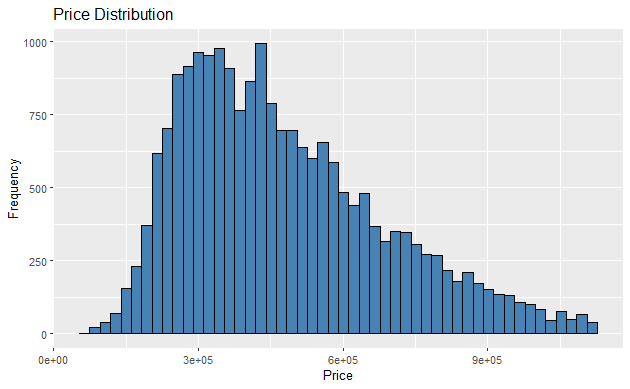

```r
# Price Distribution - Histogram
ggplot(cleaned_data_file, aes(x = price)) +
  geom_histogram(bins = 50, fill = "steelblue", color = "black") +
  labs(title = "Price Distribution", x = "Price", y = "Frequency")
```

# Observation: The histogram shows that the majority of house prices are concentrated in the lower price range, with a few high-priced homes creating a long tail.

# Interpretation: This right-skewed distribution suggests that affordable homes dominate the market, while premium properties are fewer but significantly more expensive.

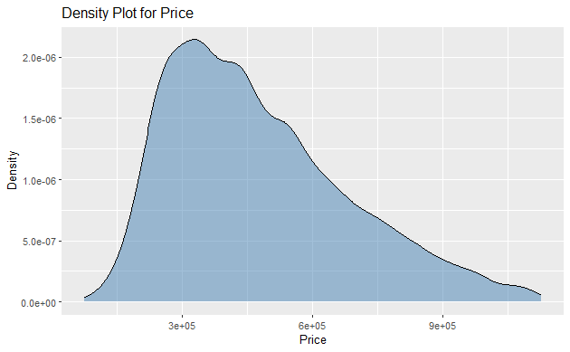

```r
# Price Distribution - Density Plot
ggplot(cleaned_data_file, aes(x = price)) +
  geom_density(fill = "steelblue", alpha = 0.5) +
  labs(title = "Density Plot for Price", x = "Price", y = "Density")
```

# Observation: The density plot supports the histogram, confirming the right-skewed distribution of house prices.

# Interpretation: The bulk of house prices are in the lower range, indicating a market dominated by affordable homes, with fewer expensive properties.

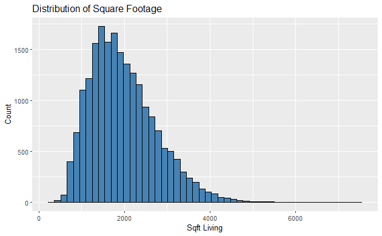

```r
# Square Footage Distribution - Histogram
ggplot(cleaned_data_file, aes(x = sqft_living)) +
  geom_histogram(bins = 50, fill = "steelblue", color = "black") +
  labs(title = "Distribution of Square Footage", x = "Sqft Living", y = "Count")
```

# Observation: Most homes have modest square footage, with some larger homes creating a right-skew in the distribution.

# Interpretation: This suggests that typical homes are of moderate size, and larger homes, which are likely more expensive, are less common.

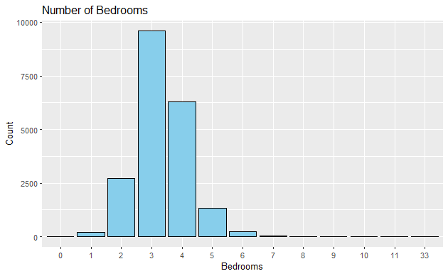

```r
# Number of Bedrooms - Bar Chart
ggplot(cleaned_data_file, aes(x = factor(bedrooms))) +
  geom_bar(fill = "skyblue", color = "black") +
  labs(title = "Number of Bedrooms", x = "Bedrooms", y = "Count")
```

# Observation: Most homes have between 2-4 bedrooms.

# Interpretation: The typical house size is suited for small to mid-sized families, reflecting general housing demand.

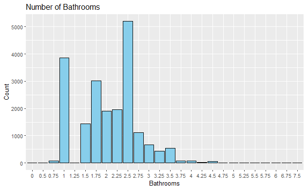

```r
# Number of Bathrooms - Bar Chart
ggplot(cleaned_data_file, aes(x = factor(bathrooms))) +
  geom_bar(fill = "skyblue", color = "black") +
  labs(title = "Number of Bathrooms", x = "Bathrooms", y = "Count")
```

# Observation: Most homes have between 1-3 bathrooms.

# Interpretation: Homes are generally built to accommodate smaller family needs, with fewer homes designed for larger households with multiple bathrooms.

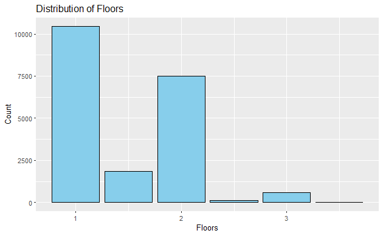

```r
# Floors Distribution - Bar Chart
ggplot(cleaned_data_file, aes(x = floors)) +
  geom_bar(fill = "skyblue", color = "black") +
  labs(title = "Distribution of Floors", x = "Floors", y = "Count")
```

# Observation: Most homes have 1-2 floors.

# Interpretation: The market is dominated by single-family homes with a conventional floor setup, while multi-floor homes are less common.

### BI-VARIATE ANALYSIS

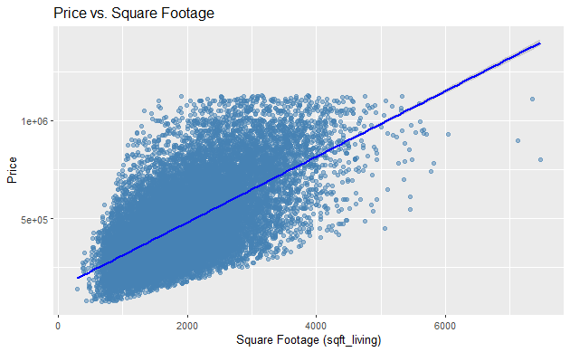

```r
# Scatterplot for Price vs. Square Footage
ggplot(cleaned_data_file, aes(x = sqft_living, y = price)) +
  geom_point(alpha = 0.5, color = "steelblue") +
  geom_smooth(method = "lm", color = "blue") +
  labs(title = "Price vs. Square Footage", x = "Square Footage (sqft_living)", y = "Price")
```

# Observation: There is a clear positive relationship between square footage and price.

# Interpretation: Larger homes tend to be more expensive, confirming that square footage is a key factor in home pricing.

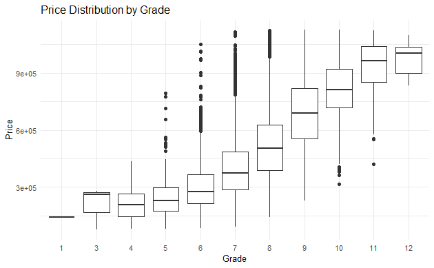

```r
# Boxplot for Price by Grade
ggplot(cleaned_data_file, aes(x = as.factor(grade), y = price)) +
  geom_boxplot() +
  labs(title = "Price Distribution by Grade", x = "Grade", y = "Price") +
  theme_minimal()
```

# Observation: Higher grades correspond to higher prices, with variation within each grade.

# Interpretation: Home quality significantly influences price, but there is still variability due to other factors like location and size.

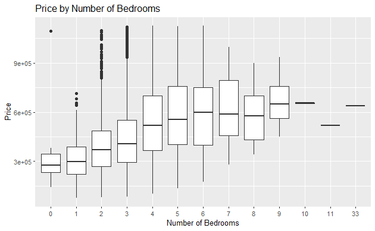

```r
# Boxplot for Price by Number of Bedrooms
ggplot(cleaned_data_file, aes(x = factor(bedrooms), y = price)) +
  geom_boxplot() +
  labs(title = "Price by Number of Bedrooms", x = "Number of Bedrooms", y = "Price")
```

# Observation: Homes with more bedrooms generally have higher prices, though there is considerable overlap in prices for homes with different numbers of bedrooms.

# Interpretation: While more bedrooms can increase the price, factors like home quality, size, and location also contribute to the overall cost.

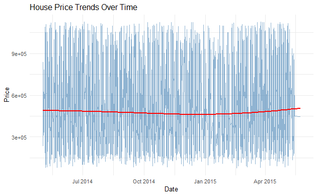

```r
# Plotting the trend of house prices over time
ggplot(cleaned_data_file, aes(x = date, y = price)) +
  geom_line(color = "steelblue", alpha = 0.6) +  # Line plot to show price trend over time
  geom_smooth(method = "loess", color = "red", se = FALSE) +  # LOESS smoothing to capture trend
  labs(title = "House Price Trends Over Time", x = "Date", y = "Price") +
  theme_minimal()
```

# Observation: The graph shows considerable daily variability in house prices from mid-2014 to early 2015. The prices fluctuate heavily from day to day, making it difficult to identify any obvious long-term trend in the data.

# Observation: The red LOESS smoothing curve indicates that, despite the fluctuations, there is only a slight upward or relatively flat movement in prices over time, suggesting minimal price change during the observed period.

# Interpretation: The lack of a clear trend in house prices could indicate that the overall market remained relatively stable during this period, with no significant long-term increase or decrease in average house prices. The day-to-day fluctuations are likely due to the varying characteristics of individual houses being sold (e.g., size, location, or condition), rather than broader market forces.

### MULTI-VARIATE ANALYSIS

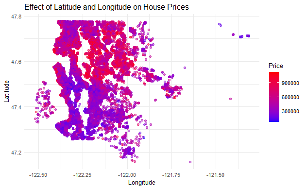

```r
# Scatter plot of latitude and longitude with house price as color scale
ggplot(cleaned_data_file, aes(x = long, y = lat, color = price)) +
  geom_point(alpha = 0.5) +
  scale_color_gradient(low = "blue", high = "red") +
  labs(title = "Effect of Latitude and Longitude on House Prices",
       x = "Longitude",
       y = "Latitude",
       color = "Price") +
  theme_minimal()
```

# Observation: Houses located closer to specific geographic coordinates, likely urban centers or waterfront areas, tend to have higher prices, as indicated by the clustering of red points (higher prices).

# Interpretation: Proximity to desirable locations, such as city centers or scenic areas, significantly raises house prices. However, other factors like house size and condition also play a role in the price variation.

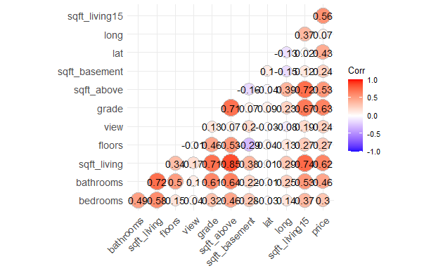

```r
# Correlation Matrix
corr_matrix <- cor(cleaned_data_file %>% select_if(is.numeric), use = "complete.obs")
ggcorrplot(corr_matrix, method = "circle", type = "lower", lab = TRUE)
```